# R Notebook for conducting Minimum Detectable Change (MDC) Analysis to design a monitoring strategy for the Upper Yaquina River TMDL Implementation Plan

## Calculate MDC using standard error of slope estimate

Use the standard error estimates to proceed with calculating the MDCs for the stations.

```r
# Calculate MDC by station using base R

# Split Data by Category
data_split <- split(df_log10, df_log10$STATION)

# Create function to be used to Fit Models and to get SE Slope for Each Category
calculate_SE <- function(df) {
  model <- lm(log10_EC_val ~ date, data = df)
  summary_model <- summary(model)

  # Extract the standard error of the slope
  SE_slope <- summary_model$coefficients["date", "Std. Error"]

  return(SE_slope)
}

# calculate SE for slope estimates by station, returns a list
SE_results <- lapply(data_split, calculate_SE)

# create data.frame of SE for slope estimates from list
df_SE <- stack(unlist(SE_results))
df_SE <- df_SE[, c("ind", "values")]
names(df_SE) <- c("STATION", "SE_slope")
df_N <- as.data.frame(table(df_log10$STATION))
names(df_N) <- c("STATION", "N")

df_SE <- inner_join(df_N, df_SE, by = "STATION")

# Determine the critical t-value
# Assuming a 95% confidence level and using n-2 degrees of freedom
confidence_level <- 0.95
# Add the degrees of freedom
df_SE <- cbind(df_SE, deg_f = df_SE$N - 2)
# Calculate critical t_values
df_SE <- cbind(df_SE,
               t_value = qt((1 - confidence_level) / 2, df_SE$deg_f))



# Calculate MDC
if(exists("df_MDC")) {rm(df_MDC)}
df_MDC <- cbind(df_SE, MDC = df_SE$N  * df_SE$t_value * df_SE$SE_slope)
df_MDC <- cbind(df_MDC, MDC_per = abs((1 - 10^(-df_MDC$MDC)) * 100))

# Print the MDC
print(df_MDC)
```

| STATION | N | SE_slope | deg_f | t_value | MDC | MDC_per |
| --- | --- | --- | --- | --- | --- | --- |
| 11476 | 233 | 1.662556e-05 | 231 | -1.970287 | -0.007632408 | 1.772960 |
| 12301 | 12 | 1.326736e-03 | 10 | -2.228139 | -0.035473829 | 8.511016 |
| 33112 | 65 | 1.239579e-04 | 63 | -1.998341 | -0.016101151 | 3.777009 |
| 34454 | 64 | 1.529235e-04 | 62 | -1.998972 | -0.019564146 | 4.607819 |
| 34455 | 11 | 1.214591e-03 | 9 | -2.262157 | -0.030223553 | 7.207101 |
| 34456 | 11 | 9.879876e-04 | 9 | -2.262157 | -0.024584816 | 5.824157 |

```r
NA
```

Here is a plot of the MDCs by station

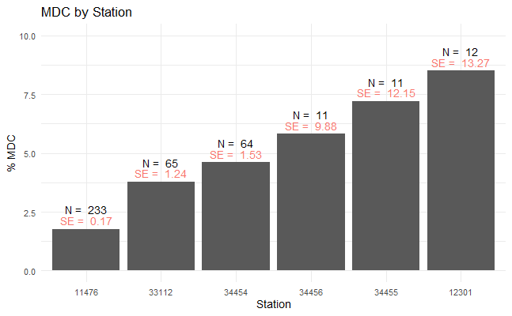

From the plot above, we can judged several important factors.

Lower MDC means we can detect smaller changes, so the lower the MDC means we can detect smaller changes in the E. coli levels that occur during implementation.

Since the MDC is based on the standard error of the slope estimate, we can detect smaller changes when we have lower standard error.

The SE depends on on several factors. A main one is the number of samples. This is very apparent in the larger changes needed (represented by the increasing MDC) among the stations.

The larger the MDC, would require more samples in the post-implementation period.

## MDC function for Varying N

I used ChatGPT 4.0 to get a starting point for the function

```r
calculateMDCWithAdditionalSamples <- function(model, additional_samples, alpha, power) {
  # Extract the standard error of the slope (SE_b) directly from the model
  SE_b <- summary(model)$coefficients[2, "Std. Error"]

  # Calculate the total number of samples (existing plus additional)
  initial_n <- length(model$model[[1]]) # Assuming the first column in model data is the response variable
  total_n <- initial_n + additional_samples

  # Calculate degrees of freedom for the total sample size
  df <- total_n - 2

  # Calculate the critical t-values for the given alpha and power
  t_alpha <- qt(1 - alpha/2, df)
  t_beta <- qt(power, df)

  # Calculate the MDC using the SE_b from the model
  # Note: This calculation assumes SE_b remains constant with additional samples, which might not be accurate
  MDC <- (t_alpha + t_beta) * SE_b * 365

  return(MDC)
}
```

Now I tried the function for station 12301, which had the largest MDC

```r
print(paste("MDC for", initial_n + additional_samples, "total samples:",
            sprintf("%.2f", abs(10^(MDC_add) - 1) * 100), "% compared to",
            sprintf("%.2f", abs(10^(MDC_cur) - 1) * 100),
            "% for", initial_n, "initial samples"))
```

[output not shown]

```
[1] "MDC for 48 total samples: 3921.69 % compared to 5439.72 % for 12 initial samples"
```

I need a way to incorporate the x data into the regression statistics and MDC. I think the approach as is assumes that each additional sample is collected at a constant step in x (or time in my case).